# Visualizaición de gráficos - Parte II

# **geom_line()**

Los gráficos de línea nos permiten poder mostrar la evolución de un fenómeno a lo largo del tiempo. Tienen la virtud de condensar información que sucedió durante días, semanas, meses o años y comparar entre estos períodos para detectar tendencias como así también situaciones “atípicas”.

En las siguientes sentencias veremos cómo crear gráficos de líneas ( función `geom_line`) con el paquete `{ggplot2}`, a través de situaciones concretas que podemos encontrar procesando la información que contiene la base del **SNIC**.

## **Caso:** Quiero conocer la evolución de víctimas por homicidio doloso a lo largo de los meses para los años 2017 a 2020. Para ello procedemos a armar la tabla resúmen con el conjunto de funciones vistas al momento del paquete `tiidyverse``:

```r
library(flipbookr)
library(tidyverse)
library(xaringanthemer)
library(xaringan)
library(gt)
library(icons)
library(here)

##~~~~~~~~~~~~~~~~~~~~~~~~~~~~~~~~~~
##  ~ Cargo la base de trabajo  ----
##~~~~~~~~~~~~~~~~~~~~~~~~~~~~~~~~~~
base_snic <- read_csv2("../data/snic-departamentos-mes-sexo.csv")

# Armo tabla
tabla_victimas <- base_snic %>%
  filter(!is.na(cantidad_victimas) & codigo_delito_snic_id == 1) %>%
  mutate(periodo = paste0(anio, "_", mes)) %>%
  group_by(periodo) %>%
  summarise(cant_victimas_h_doloso = sum(cantidad_victimas, na.rm = TRUE))
```

```r
### Carglo la librería
library(tidyverse)

### Cargo la base de trabajo
base_snic <- read_csv2("../data/snic-departamentos-mes-sexo.csv")

# Armo tabla
tabla_victimas <- base_snic %>%
  filter(!is.na(cantidad_victimas) & codigo_delito_snic_id == 1) %>%
  mutate(periodo = paste0(anio, "_", mes),
         anio_mes = lubridate::ym(periodo)) %>%
  group_by(anio_mes) %>%
  summarise(cant_victimas_h_doloso = sum(cantidad_victimas, na.rm = TRUE))
```

Una vez construída, nuestra tabla se ve así:

```r
tabla_victimas
```

```
## # A tibble: 48 x 2
##    anio_mes   cant_victimas_h_doloso
##    <date>                      <dbl>
##  1 2017-01-01                    234
##  2 2017-02-01                    212
##  3 2017-03-01                    212
##  4 2017-04-01                    196
##  5 2017-05-01                    181
##  6 2017-06-01                    180
##  7 2017-07-01                    183
##  8 2017-08-01                    189
##  9 2017-09-01                    150
## 10 2017-10-01                    177
## # ... with 38 more rows
## # i Use `print(n = ...)` to see more rows
```

## Procedemos a armar el gráfico, identificando qué variables irán en qué ejes y definiendo el tipo de geometría a utilizar para un gráfico de líneas:

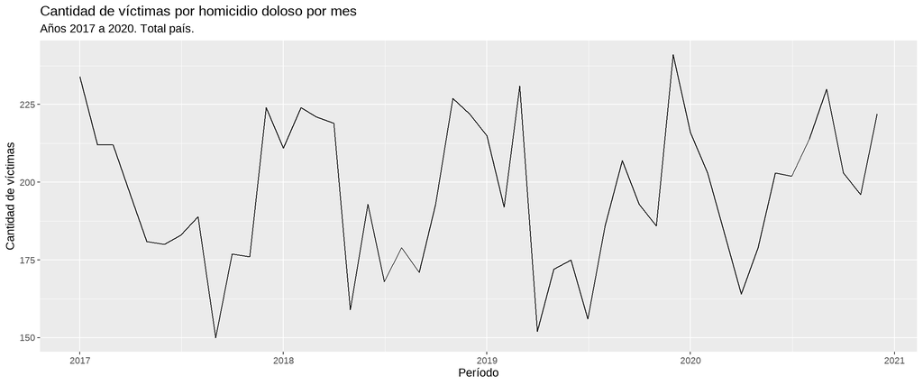

```r
grafico_victimas <- tabla_victimas %>%
  ggplot(
    aes(x = anio_mes,
        y = cant_victimas_h_doloso,
        group = "")) +
  geom_line() +
  labs(title = "Cantidad de víctimas por homicidio doloso por mes",
       subtitle = "Años 2017 a 2020. Total país.",
       x = "Período",
       y = "Cantidad de víctimas")

grafico_victimas
```

### Emprolijemos

con la función `scale_x_date()` se puede operar sobre el eje x, en nuestro caso con valores de tipo fecha. Así, definiendo el parametro `date_breaks =` podemos indicar cada cuaánto queremos que se muestren los valores en el eje, y evitar un “embotellamiento” de etiquetas que obstruyan la lectura del gráfico y permitan llegar mejor a conclusiones rápidas sobre la información producida.

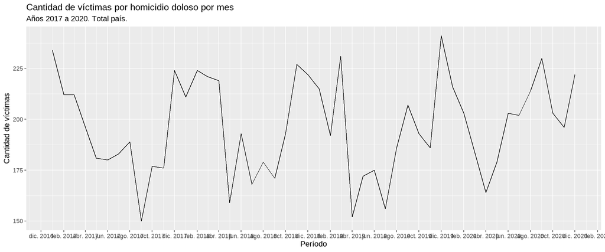

```r
grafico_victimas +
    scale_x_date(date_breaks = "2 month",
               date_labels = '%b %Y')
```

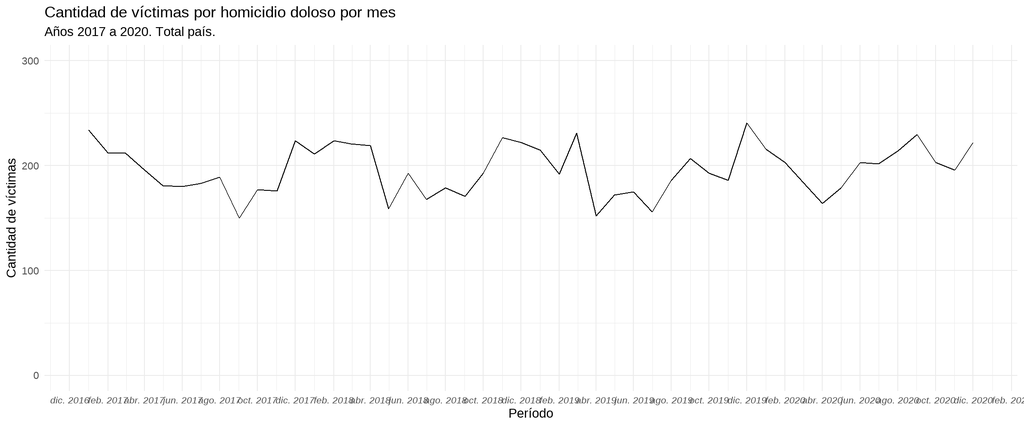

```r
grafico_victimas +
    scale_x_date(date_breaks = "2 month",
               date_labels = '%b %Y') +
  ylim(0, 300) +
  theme_minimal() +
  theme(
    axis.text.x = element_text(size = 8,
                               face = "italic"))
```

# **Recursos para *aesthetics*, *escalas* y *themes*:**

- https://ggplot2tor.com/aesthetics/
- https://ggplot2tor.com/scales/
- https://henrywang.nl/ggplot2-theme-elements-demonstration/

### Ahora quiero ver la cantidad de víctimas pero comparando por género para el mismo período. Procedemos entonces a armar nuestra tabla con los datos para poder graficar:

```r
tabla_victimas_x_mes <- base_snic %>%
  filter(!is.na(cantidad_victimas) & codigo_delito_snic_id == 1) %>%
  mutate(periodo = paste0(anio, "_", mes),
         anio_mes = lubridate::ym(periodo)) %>%
  pivot_longer(cols = starts_with("victimas_"),
               names_to = "genero_victima",
               values_to = "cantidad") %>%
  group_by(anio_mes, genero_victima) %>%
  summarise(cantidad = sum(cantidad))

tabla_victimas_x_mes %>%
  head()
```

```
## # A tibble: 6 x 3
## # Groups:   anio_mes [2]
##   anio_mes   genero_victima     cantidad
##   <date>     <chr>                 <dbl>
## 1 2017-01-01 victimas_femenino        36
## 2 2017-01-01 victimas_masculino      190
## 3 2017-01-01 victimas_no_consta        8
## 4 2017-02-01 victimas_femenino        38
## 5 2017-02-01 victimas_masculino      174
## 6 2017-02-01 victimas_no_consta        0
```

### Ahora sí, el gráfico. Como la idea es poder conocer la evolución de la cantidad de víctimas en el tiempo, pero ahora diferenciando por el género de la víctima, debemos prestarle atención a los parámetros `color =` (con quien le daremos el color a la línea según el género) y `group =` que permitirá diferenciar las tres líneas en el gráfico.

Al final, se puede apreciar que también podemos introducir modificaciones más bien *estéticas* para mejorar la visualización. para ello recurrimos a la función `theme()`, desde donde podemos setear el fondo del gráfico (con `panel.background =`), el tamaño y el tipo de letra de las etiquetas en el eje x (con `axis.text.x =`) o la posición de la legenda (con `legend.position =`).

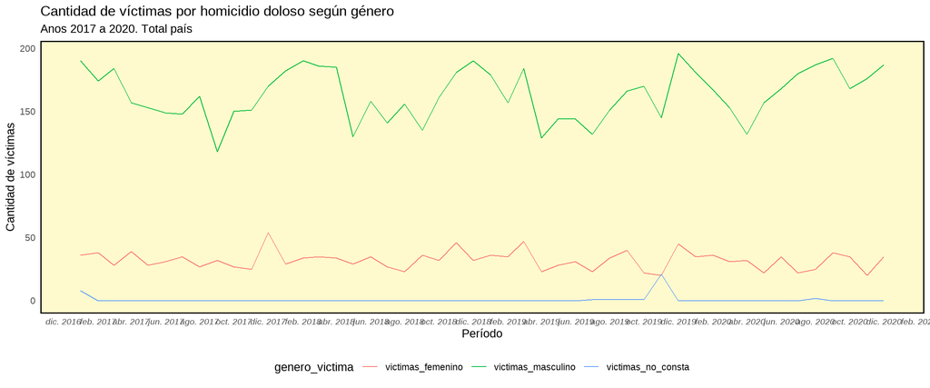

```r
ggplot(data = tabla_victimas_x_mes,
  aes(x = anio_mes,
      y = cantidad,
      color = genero_victima,
      group = genero_victima)) +
  geom_line(stat='summary') +
  scale_x_date(date_breaks = "2 month",
               date_labels = '%b %Y') +
  labs(title = "Cantidad de víctimas por homicidio doloso según género",
       subtitle = "Anos 2017 a 2020. Total país",
       x = "Período",
       y = "Cantidad de víctimas",
       fill = "Género de la víctima") +
  theme_minimal() +
  theme(
    axis.text.x = element_text(size = 8, face = "italic"),
    panel.grid = element_blank(),
    panel.background = element_rect(fill = "lemonchiffon", colour = "black", size = 1),
    legend.position = "bottom")
```

### Creo mi propio theme.

Con la siguiente sentencia podemos crear nuestro propio `theme()`, para luego no tener que definir en todos los gráficos el conjunto de estéticas. Ejemplo:

```r
theme_pablo <- function() {

  theme(
    # plotting components

    ## Cambiamos las líneas de la grilla
    panel.grid.minor = element_blank(),
    panel.grid.major =  element_line(color = "#d0d0d0"),
    # Fondo del panel y de la imágen + bordes
    panel.background = element_rect(fill = "#f0f0f0", color = NA),
    plot.background = element_rect(fill = "#f0f0f0", color = NA),
    panel.border = element_blank(),
    # Márgenes del gráfico and remove axis ticks
    plot.margin = margin(0.5, 1, 0.5, 1, unit = "cm"),
    axis.ticks = element_blank(),
    # Cambio de fuentes, tamaño y posición en títulos
    text = element_text(size = 12),
    axis.text = element_text(face = "bold", color = "grey", size = 12),
    axis.title = element_text(face = "bold", size = rel(1.33)),
    axis.title.x = element_text(margin = margin(0.5, 0, 0, 0, unit = "cm")),
    axis.title.y = element_text(margin = margin(0, 0.5, 0, 0, unit = "cm"), angle =90),
    plot.title = element_text(face = "bold", size = rel(1.67), hjust = 0),
    plot.title.position = "plot",
    plot.subtitle = element_text(size = 16, margin = margin(0.2, 0, 1, 0, unit = "cm"), hjust = 0),
    plot.caption = element_text(size = 10, margin = margin(1, 0, 0, 0, unit = "cm"), hjust = 1),
    strip.text = element_text(size = rel(1.33), face = "bold")
  )
}
```

### Aplico el nuevo theme

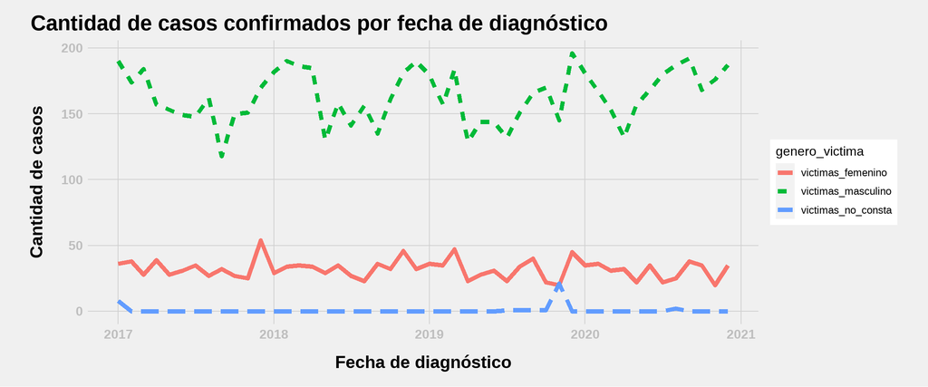

```r
tabla_victimas_x_mes %>%
  ggplot(aes(x = anio_mes,
             y = cantidad,
             color = genero_victima,
             linetype = genero_victima)) +
  geom_line(aes(group = genero_victima),
            size = 2) +
  labs(title = "Cantidad de casos confirmados por fecha de diagnóstico",
       x = "Fecha de diagnóstico",
       y = "Cantidad de casos") +
  theme_pablo()
```